# Designing and Creating Relational Database for Doctor-Patient Appointments

Published

November 12, 2025

**Important**

The coding phase is officially finished! I’m now working on turning the insights and results from this repo into a full-length article. In the meantime, feel free to check out the source code and documentation right [here](https://github.com/daffadaniel/03-DatabaseDesign).

# **Project Overview**

This project showcases my capabilities in relational database design, data modeling, and SQL schema implementation. The primary goal was to design an **efficient, consistent, and scalable** database schema to support the operations of a hospital management system.

The resulting tables has been normalized up to the **Third Normal Form (3NF)** to minimize data redundancy and ensure data integrity.

Github: Link

## Key Features

- **Entity-Relationship Modeling (ERD):** Creation of a comprehensive relationship diagram to visualize the data structure.
- **Data Normalization:** Application of normalization rules to achieve storage efficiency and integrity.
- **SQL Schema Definition:** Implementation of complete SQL DDL (`CREATE TABLE`) scripts, including constraints (`PRIMARY KEY`, `FOREIGN KEY`, `UNIQUE`, `CHECK`).
- **Data Documentation:** Detailed explanation of each table, column, and relationship.
- **Data Population (Dummy Data):** Generation of realistic and relevant dummy data using the Faker library in Python to populate the tables, ensuring the schema is thoroughly tested with substantial, simulated data.

## Entity Relationship Diagram

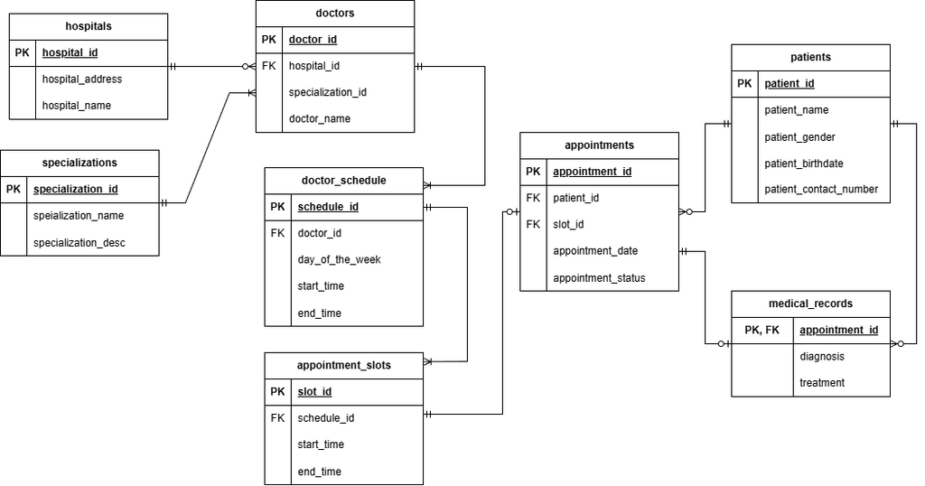

hospital appointment system erd

# Full Code & Details

Here’s walkthrough on how I design the database system for doctor appointment.

### Mission Statement

Design and implement a well-structured relational database system for a hospital that covers patient registration, doctor, and appointment management.

### Creating Table Structures

From the mission stated above, let’s breakdown the tables needed for the databases.

Clearly, we need `patients`,`doctors`, and `appointments` as tables. We can also add `hospitals` to accomodate more than one hospital.

| Table | Description |
| --- | --- |
| patients | stores each patient detailed information |
| doctors | stores each doctor detailed information |
| appointments | stores each appointment detailed information |
| hospitals | stores hospital detailed information |

Now, let’s determine the fields for each tables:

| patients | doctors | appointments | hospitals |
| --- | --- | --- | --- |
| patient_id | doctor_id | appointment_id | hopital_id |
| patient_name | hospital_id | patient_id | hospital_address |
| patient_gender | doctor_name | appointment_date | hospital_name |
| patient_birthdate | specialization | doctor_id |  |
| patient_contact_number |  | appointment_status |  |

Each data will have its own identifier, the `_id` field, and then the other fields stores the information. However, this table appears to be incomplete as it does not include specific appointment times or doctors’ practice schedules. Doctors usually have practice schedules with specific days and hours. So, to accomodate this we need to add `doctor_schedule` to our list of tables.

| Table | Description |
| --- | --- |
| doctors_schedule | stores each doctors schedule |

The field for this table:

| doctors_schedule |
| --- |
| schedule_id |
| doctor_id |
| day_of_the_week |
| start_time |
| end_time |

An appointment must have a specific time and be confirmed on the selected doctor’s schedule. So, to make the appointment time more managable, We must divide the doctor’s practice hours into several slots to choose from as the patient’s appointment time.

| Table | Description |
| --- | --- |
| appointment_slots | stores appointment slot according to each doctor schedule |

The fields for this table:

| appointment_slots |
| --- |
| slot_id |
| schedule_id |
| start_time |
| end_time |

Later, we can fill it in automatically from each doctor’s schedule. For example, if a doctor’s consultation is estimated to last 30 minutes, then appointment slots will be created every 30 minutes in their practice schedule.

Finally, we must create a table that stores the results of each doctor’s completed appointment with the patient.

| Table | Description |
| --- | --- |
| medical_records | stores each patients appointment diagnosis and treatment |

The fields for this table:

| medical_records |
| --- |
| appointment_id |
| diagnosis |
| treatment |

Additionally, to prevent inconsistencies of `specialization` names, We can create validation table for it.

| Table | Description |
| --- | --- |
| specializations | stores all type of doctor specialization and it’ description |

The fields for this table:

| specializations |
| --- |
| specialization_id |
| specialization_name |
| specialization_desc |

### Determine Table Relationships

Each table `_id` field should be the primary key of its table and be a foreign key if it occurs on other table.

Let’s start by determining the relation between hospital and doctor table:

So, the relation of hospital table to doctor table is `one-mandatory` to `many-optional`.

Using similar logic and method, we do this for all connected tables and here is the result:

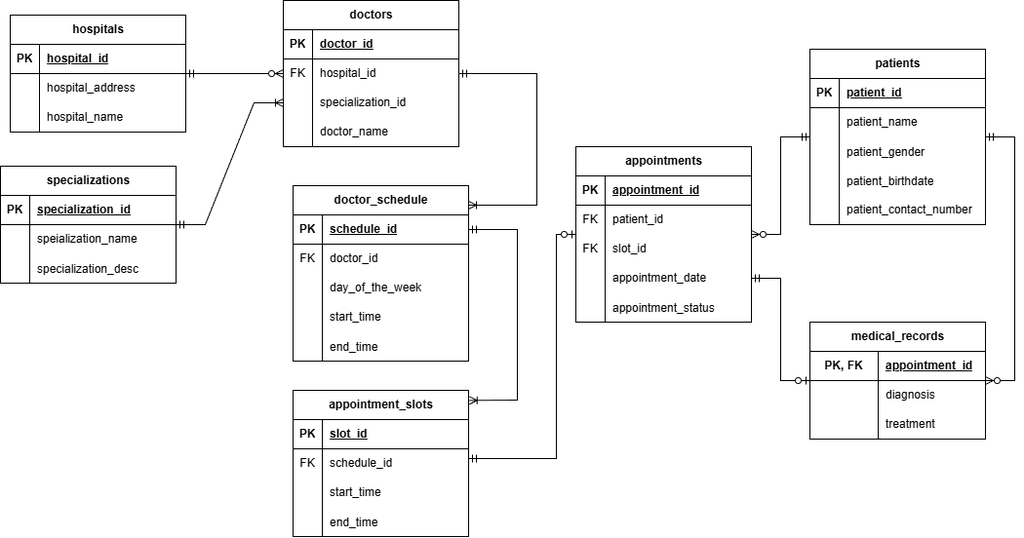

hospital appointment system erd

### Determine Business Rules

#### 1. Patients

- Each patient must have a unique patient ID.
- A patient’s gender must be either “Male” or “Female” .
- A patient can have multiple appointments.
- If a patient is deleted, all of their appointments must also be deleted.

#### 2. Hospitals

- Each hospital must have a hospital name (it cannot be NULL).
- If a hospital is deleted, doctors assigned to it remain in the system but their hospital_id becomes NULL.

#### 3. Specializations

- Each specialization must have a unique name.
- A doctor may exist without a specialization.
- If a specialization is deleted, doctors linked to it will have their specialization_id set to NULL.

#### 4. Doctors

- A doctor may have multiple schedules.
- If a doctor is deleted, all related schedules and appointment slots must be deleted.

#### 5. Doctor Schedules

- Each doctor schedule must specify a day of the week and a start/end time.
- A doctor can have multiple schedules.
- If a doctor is deleted, all of their schedules must also be removed.
- Appointment slots depend on these schedules.

#### 6. Appointment Slots

- Each appointment slot must belong to a doctor’s schedule.
- If a schedule is deleted, all associated appointment slots must also be deleted.
- Each slot contains a defined start and end time.

#### 7. Appointments

- Each appointment must be linked to a patient.
- The appointment may optionally be linked to a slot (slot_id can be NULL).
- This can happen if the slot is deleted (slot_id becomes NULL).
- Appointment status must be one of the following:
  - Scheduled
  - Completed
  - Cancelled
- No two appointments can use the same slot on the same date.
- If a patient is deleted, all their appointments are deleted.
- If a slot is deleted, the appointment remains but the slot_id becomes NULL.

#### 8. Medical Records

- Each medical record must be associated with exactly one appointment.
- A medical record cannot exist without a valid appointment.
- If an appointment is deleted, the medical record must also be deleted.

### Implementing a Relational Database

```sql
-- Patient
CREATE TABLE patients (
    patient_id SERIAL PRIMARY KEY,
    patient_name VARCHAR(100),
    patient_gender VARCHAR(10) CHECK (patient_gender IN ('Male', 'Female')),
    patient_birthdate DATE,
    patient_contact_number VARCHAR(100)
);

-- Hospital
CREATE TABLE hospitals(
    hospital_id SERIAL PRIMARY KEY,
    hospital_name VARCHAR(100) NOT NULL,
    hospital_address VARCHAR(100)
);

-- specializations
CREATE TABLE specializations(
    specialization_id SERIAL PRIMARY KEY,
    specialization_name VARCHAR(100) UNIQUE NOT NULL,
    specialization_desc TEXT
);

-- Doctors
CREATE TABLE doctors(
    doctor_id SERIAL PRIMARY KEY,
    hospital_id INT NULL,
    specialization_id INT NULL,
    doctor_name VARCHAR(100),
    CONSTRAINT fk_specializations
        FOREIGN KEY(specialization_id)
        REFERENCES specializations(specialization_id)
        ON UPDATE CASCADE
        ON DELETE SET NULL,
    CONSTRAINT fk_hospitals
        FOREIGN KEY(hospital_id)
        REFERENCES hospitals(hospital_id)
        ON UPDATE CASCADE
        ON DELETE SET NULL
);


-- Doctor Schedule
CREATE TABLE doctor_schedule(
    schedule_id SERIAL PRIMARY KEY,
    doctor_id INT,
    day_of_week VARCHAR(10),
    start_time TIME,
    end_time TIME,
    CONSTRAINT fk_doctors
        FOREIGN KEY(doctor_id)
        REFERENCES doctors(doctor_id)
        ON DELETE CASCADE
        ON UPDATE CASCADE
);

-- Tabel Appointment slot
CREATE TABLE appointment_slots(
    slot_id SERIAL PRIMARY KEY,
    schedule_id INT,
    start_time TIME,
    end_time TIME,
    CONSTRAINT fk_doctor_schedule
        FOREIGN KEY(schedule_id)
        REFERENCES doctor_schedule(schedule_id)
        ON DELETE CASCADE
        ON UPDATE CASCADE
);

-- appointment
CREATE TABLE appointments(
    appointment_id SERIAL PRIMARY KEY,
    patient_id INT,
    slot_id INT NULL,
    appointment_date DATE,
    appointment_status VARCHAR(20) CHECK (appointment_status IN ('Scheduled', 'Completed', 'Cancelled'))
    DEFAULT 'Scheduled',
    CONSTRAINT fk_patient
        FOREIGN KEY(patient_id)
        REFERENCES patients(patient_id)
        ON UPDATE CASCADE
        ON DELETE CASCADE,
    CONSTRAINT fk_appointment_slot
        FOREIGN KEY(slot_id)
        REFERENCES appointment_slots(slot_id)
        ON UPDATE CASCADE
        ON DELETE SET NULL,
    CONSTRAINT unique_appointment_slot UNIQUE (slot_id, appointment_date)
);

-- medical records
CREATE TABLE medical_records(
    appointment_id INT PRIMARY KEY,
    diagnosis TEXT,
    treatment TEXT,
    CONSTRAINT fk_appointments
        FOREIGN KEY(appointment_id)
        REFERENCES appointments(appointment_id)
        ON UPDATE CASCADE
        ON DELETE CASCADE
);
```

## Populating the Database

All data in this project were synthetically generated using `Faker` and `random` library in Python.

## Sample SQL Queries

The following are sample `SQL` queries you can do on `hospital_app-db`.

```sql
SELECT doctor_name, hospital_name
FROM doctors
LEFT JOIN hospitals
    ON  doctors.hospital_id = hospitals.hospital_id
LEFT JOIN specializations
    ON doctors.specialization_id = specializations.specialization_id
```

`Output`:

[figure not shown]

### 2. Patient’s scheduled appointment

```sql
CREATE VIEW full_appointments AS
SELECT
    a.appointment_id,
    a.appointment_date,
    a.appointment_status,
    p.patient_id,
    p.patient_name,
    spec.specialization_id,
    spec.specialization_name,
    d.doctor_id,
    d.doctor_name,
    h.hospital_name,
    h.hospital_address,
    s.start_time AS slot_start_time,
    s.end_time AS slot_end_time
FROM appointments a
JOIN patients p
    ON a.patient_id = p.patient_id
JOIN appointment_slots s
    ON a.slot_id = s.slot_id
JOIN doctor_schedule ds
    ON s.schedule_id = ds.schedule_id
JOIN doctors d
    ON ds.doctor_id = d.doctor_id
JOIN hospitals h
    ON d.hospital_id = h.hospital_id
JOIN specializations spec
    ON d.specialization_id = spec.specialization_id;

SELECT *
FROM full_appointments
```

`Output`:

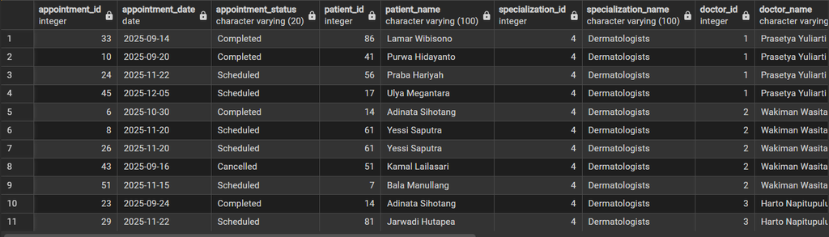

```sql
SELECT *
FROM full_appointments
WHERE appointment_status = 'Scheduled'
```

`Output`:

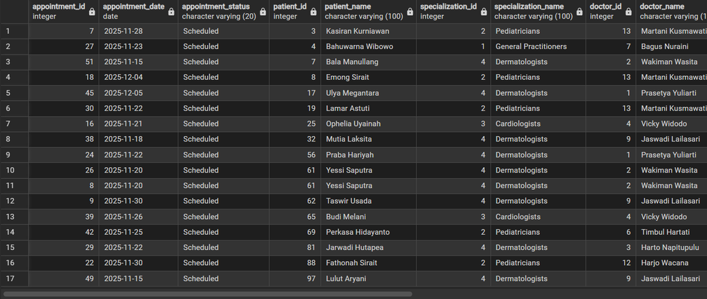

### 3. Patient’s Medical Records

```sql
SELECT appointment_date, patient_name, diagnosis, treatment
FROM medical_records
JOIN appointments
    on medical_records.appointment_id = appointments.appointment_id
JOIN patients
    ON  appointments.patient_id = patients.patient_id
```

`Output`:

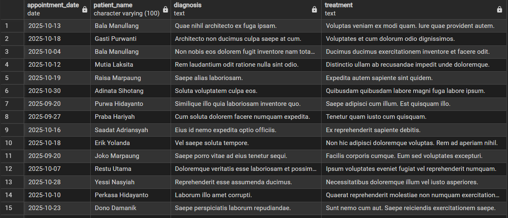

### 4. Creating new appointment

```sql
INSERT INTO appointments (patient_id, slot_id, appointment_date, appointment_status)
VALUES (7, 25, '2025-11-15', 'Scheduled');
```

### 5. Doctors with the most appointment

```sql
SELECT
    doctor_name,
    COUNT(doctor_name) AS appoinment_count,
    specialization_name
FROM full_appointments
GROUP BY doctor_name, specialization_name
ORDER BY appoinment_count DESC
LIMIT 5
```

`Output`:

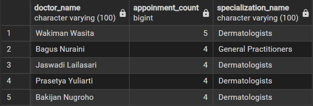

### 6. Doctors with the most ‘completed’ appointment

```sql
SELECT
    doctor_name,
    COUNT(doctor_name) AS appoinment_count,
    specialization_name
FROM full_appointments
WHERE appointment_status = 'Completed'
GROUP BY doctor_name, specialization_name
ORDER BY appoinment_count DESC
LIMIT 5
```

`Output`:

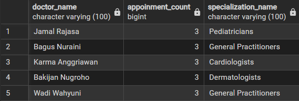

### 7. Specializations with the most cancelled appointment

```sql
SELECT
    specialization_name,
    COUNT(specialization_name) AS spec_count
FROM full_appointments
WHERE appointment_status = 'Cancelled'
GROUP BY specialization_name
ORDER BY spec_count DESC
LIMIT 5
```

`Output`:

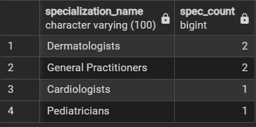

### 8. Specializations with the most patients

```sql
SELECT
    specialization_name,
    COUNT(DISTINCT patient_name) AS patient_count
FROM full_appointments
GROUP BY specialization_name
ORDER BY patient_count DESC
LIMIT 5
```

`Output`:

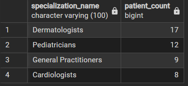

### 9. Number of Specialist in each hospital

```sql
SELECT
    hospital_name,
    specialization_name,
    COUNT(specialization_name) AS spec_count
FROM doctors
JOIN hospitals
    ON doctors.hospital_id = hospitals.hospital_id
JOIN specializations
    ON doctors.specialization_id = specializations.specialization_id
GROUP BY hospital_name, specialization_name
ORDER BY hospital_name, specialization_name, spec_count
```

`Output`:

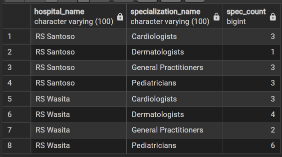